## Findings

Based on the nature of our problem, our model needs to come up with one result which is wither the customer we’re assisting has good credit or bad credit. We already have a distinct and well defined classes and want to predict it for unseen/new customers. We believe that classification methods are more suited for our dataset. The IG ID3 with 10 folds is what we choose to go with. Another factor is since our class label is known “the class attribute” which is better suited in the classification process, we didn’t have to remove it like we did in the clustering process. for that reason we believe that the classification is better for our data set giving us the best results in comparison with clustering.

```r
# Print and plot the decision tree
 print(id3_model)
```

```
## n= 894
##
## node), split, n, loss, yval, (yprob)
##       * denotes terminal node
##
##   1) root 894 269 1 (0.3008949 0.6991051)
##     2) checking_status=2,4 482 215 1 (0.4460581 0.5539419)
##       4) property_magnitude=1,2,3 358 176 0 (0.5083799 0.4916201)
##         8) credit_history=1,2 53  13 0 (0.7547170 0.2452830) *
##         9) credit_history=3,4,5 305 142 1 (0.4655738 0.5344262)
##          18) duration>=23.5 91  33 0 (0.6373626 0.3626374) *
##          19) duration< 23.5 214  84 1 (0.3925234 0.6074766)
##            38) purpose=domestic appliance,education,new car,other,repairs 77  33 0 (0.5714286 0.4285714)
##              76) personal_status=female div/dep/mar,male mar/wid 33   9 0 (0.7272727 0.2727273)
##               152) duration>=7.5 26   4 0 (0.8461538 0.1538462) *
##               153) duration< 7.5 7   2 1 (0.2857143 0.7142857) *
##              77) personal_status=male div/sep,male single 44  20 1 (0.4545455 0.5454545)
##               154) savings_status=1,2,5 36  16 0 (0.5555556 0.4444444)
##                 308) credit_amount>=4145 10   2 0 (0.8000000 0.2000000) *
##                 309) credit_amount< 4145 26  12 1 (0.4615385 0.5384615)
##                   618) credit_amount< 900 7   1 0 (0.8571429 0.1428571) *
##                   619) credit_amount>=900 19   6 1 (0.3157895 0.6842105) *
##               155) savings_status=3,4 8   0 1 (0.0000000 1.0000000) *
##            39) purpose=business,furniture/equipment,radio/tv,retraining,used car 137  40 1 (0.2919708 0.7080292) *
##       5) property_magnitude=4 124  33 1 (0.2661290 0.7338710) *
##     3) checking_status=1,3 412  54 1 (0.1310680 0.8689320) *
```

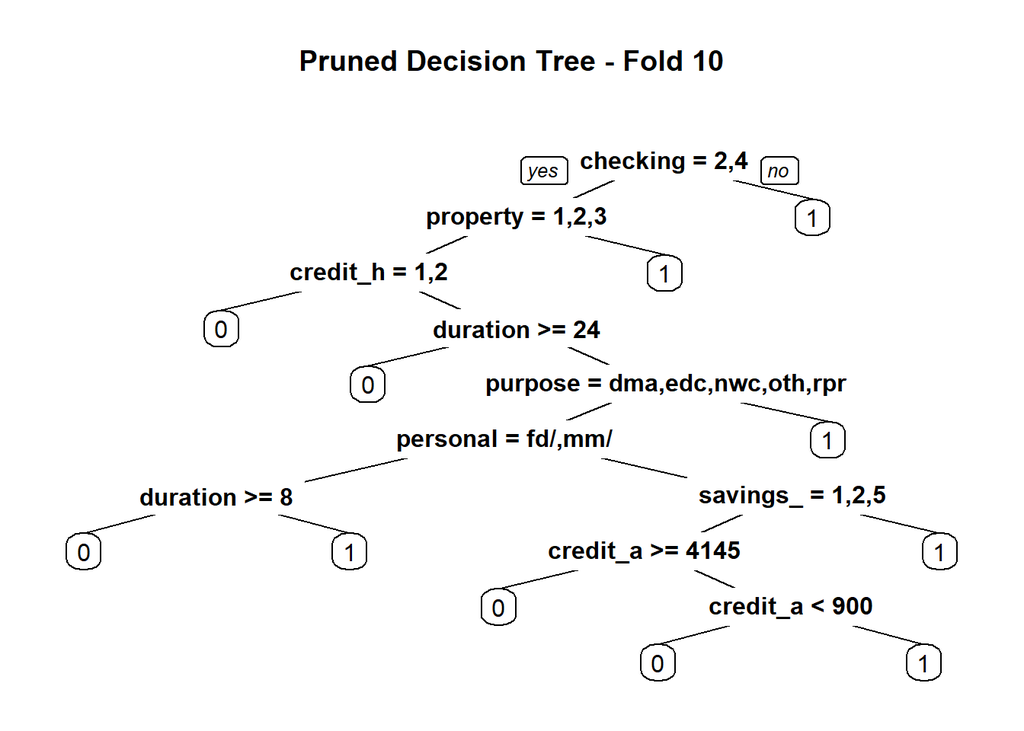

```r
 prp(id3_model, uniform = TRUE, main = paste("Pruned Decision Tree - Fold", fold))
```

this is the best decision tree IG

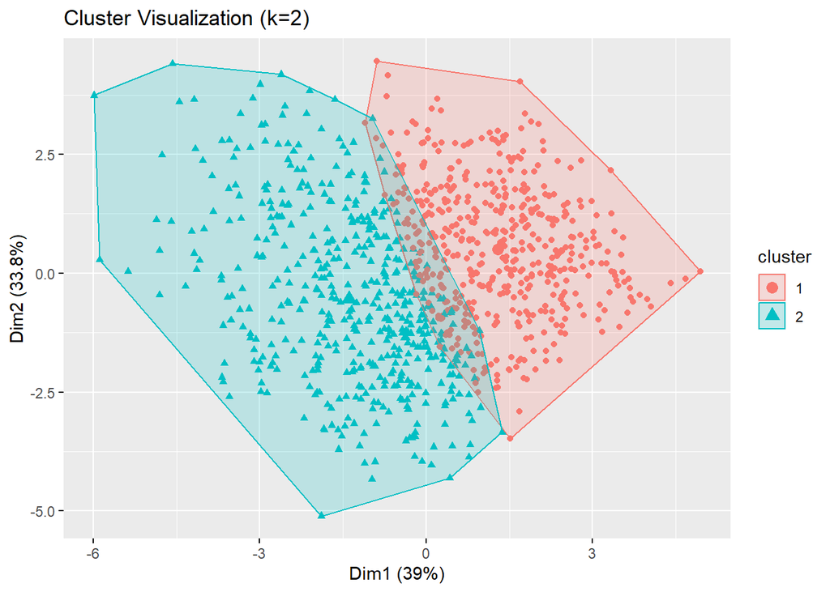

```r
# Clustering for k = 2
k2 <- kmeans(data_pca_df, centers = 2, nstart = 25)
fviz_cluster(k2, data = data_pca_df, geom = "point",
             stand = FALSE, ellipse  = TRUE,
             main = "Cluster Visualization (k=2)")
```

```r
print(paste("Total WSS for k=2:", k2$tot.withinss))
```

```
## [1] "Total WSS for k=2: 6122.19780057585"
```

```r
sil_widths2 <- silhouette(k2$cluster, dist_matrix)
avg_sil_width2 <- mean(sil_widths2[, "sil_width"])
print(paste("Average Silhouette Width for k=2:", avg_sil_width2))
```

```
## [1] "Average Silhouette Width for k=2: 0.0447772146462416"
```

this is the best clustering graph